# Laura Raveling: Conversation Gaps

RePsychLing in SMLP2022

Author

Reinhold Kliegl

Published

August 25, 2022

# 1 Questions

1. What exactly is singularity and how do i prevent it?
2. qa2: If the Person is nested within the Dyad, and the head gestures are nested within the Person, is the structure of random effects defined accurately that way?
3. How to specify the relative covariance factor?

# 2 Data Description

The data is a randomly sampled subset of variables of a conversation experiment. The experimental data consists of video recordings of conversations taking place between two participants (N Participants = 14, N Dyads = 7). The conversation is analysed with an event-related coding approach. Each time a question-answer sequence occurs, gestural interactions and turn gaps (time interval between question and answer) are annotated. The Hypothesis is that turn gap durations vary along with the type of head gestures. If there is a significant main effect, the second assumption is that head shakes go along with longer turn gap durations than head nods or head tilts. The types of head gestures are listed below the data summary and basic model specification.

# 3 Design

```r
gh.link <- "https://raw.githubusercontent.com/lraveling/smlp/main/smlp_data.txt"
df.lme <- read.delim(gh.link, sep = " ", header = TRUE, stringsAsFactors = TRUE)
#View(df.lme)
summary(df.lme)
```

```
  head.sample   dyad.sample         answer.t       g.dur       id.a    id.q
 uds    : 54   Min.   :1.000   nonverbal:231   Min.   :150.0   A:235   A:235
 lrs    : 48   1st Qu.:2.000   speech   :239   1st Qu.:228.2   B:235   B:235
 duti   : 47   Median :4.000                   Median :324.0
 fne    : 46   Mean   :3.938                   Mean   :320.8
 dus    : 44   3rd Qu.:6.000                   3rd Qu.:408.8
 rti    : 44   Max.   :7.000                   Max.   :500.0
 (Other):187
```

```r
stview(dfSummary(df.lme))
```

```
Switching method to 'browser'
```

```
Output file written: /var/folders/nd/l59kkqd951xdb29k4rt4yzj80000gn/T//Rtmp0lfhmo/file1642a34677c29.html
```

# 4 Boxplot of gap duration (y) over head gestures (x)

**head gestures (14, 3 missing in data)

- lt = left turn (-)
- rt = right turn (-)
- lti = left tilt
- rti = right tilt
- uti = upward tilt (-)
- dti = downward tilt
- fne = forward neck extension
- bne = backward neck extension
- udti = upward-downward tilt
- duti = downward-upward tilt
- lrs = left-right shake
- rsl = right-left shake
- uds = upward-downward shake
- dus = downward-upward shake

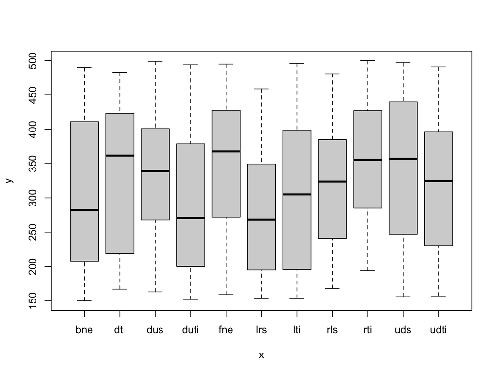

```r
plot(df.lme$head.sample,df.lme$g.dur)
```

# 5 Linear Mixed Models

RK: I changed the LMM formulas to Bates’s default specification

- adding `REML=FALSE`
- adding `control=lmerControl(calc.derivs=FALSE)`
- suppress output of correlations of fixed effects
- to be done: contrasts for head.sample (max=10) to test hypotheses

## 5.1 Original LMMs

```r
base <- lmer(g.dur ~ head.sample + (1 | head.sample), data = df.lme,
             REML=FALSE, control=lmerControl(calc.derivs=FALSE))
```

```
boundary (singular) fit: see help('isSingular')
```

```r
print(summary(base),corr=FALSE)
```

```
Linear mixed model fit by maximum likelihood  ['lmerMod']
Formula: g.dur ~ head.sample + (1 | head.sample)
   Data: df.lme
Control: lmerControl(calc.derivs = FALSE)

     AIC      BIC   logLik deviance df.resid
  5702.1   5756.1  -2838.0   5676.1      457

Scaled residuals:
     Min       1Q   Median       3Q      Max
-1.82873 -0.85475  0.03215  0.82660  1.95658

Random effects:
 Groups      Name        Variance Std.Dev.
 head.sample (Intercept)     0      0.0
 Residual                10289    101.4
Number of obs: 470, groups:  head.sample, 11

Fixed effects:
                Estimate Std. Error t value
(Intercept)      307.297     16.676  18.427
head.sampledti    27.676     23.428   1.181
head.sampledus    24.521     22.626   1.084
head.sampleduti  -11.765     22.294  -0.528
head.samplefne    37.203     22.400   1.661
head.samplelrs   -25.172     22.191  -1.134
head.samplelti    -1.714     23.747  -0.072
head.samplerls    12.176     23.428   0.520
head.samplerti    42.748     22.626   1.889
head.sampleuds    29.999     21.648   1.386
head.sampleudti    9.597     23.428   0.410
optimizer (nloptwrap) convergence code: 0 (OK)
boundary (singular) fit: see help('isSingular')
```

```r
qa1 <- lmer(g.dur ~ head.sample + (head.sample | dyad.sample), data = df.lme,
             REML=FALSE, control=lmerControl(calc.derivs=FALSE))
```

```
boundary (singular) fit: see help('isSingular')
```

```r
print(summary(qa1),corr=FALSE)
```

```
Linear mixed model fit by maximum likelihood  ['lmerMod']
Formula: g.dur ~ head.sample + (head.sample | dyad.sample)
   Data: df.lme
Control: lmerControl(calc.derivs = FALSE)

     AIC      BIC   logLik deviance df.resid
  5821.2   6145.1  -2832.6   5665.2      392

Scaled residuals:
     Min       1Q   Median       3Q      Max
-2.26707 -0.85295  0.07471  0.82766  2.12000

Random effects:
 Groups      Name            Variance Std.Dev. Corr
 dyad.sample (Intercept)      733.943 27.091
             head.sampledti   514.761 22.688   -1.00
             head.sampledus   203.819 14.277   -0.21  0.22
             head.sampleduti 2521.641 50.216   -0.88  0.88  0.65
             head.samplefne  1381.661 37.171   -0.81  0.80 -0.41  0.42
             head.samplelrs  1680.577 40.995   -0.94  0.94 -0.14  0.66  0.96
             head.samplelti   993.960 31.527    0.01 -0.02 -0.98 -0.49  0.58
             head.samplerls   887.861 29.797   -0.87  0.87 -0.30  0.53  0.99
             head.samplerti   946.533 30.766   -0.85  0.85  0.70  1.00  0.37
             head.sampleuds     7.633  2.763    0.03 -0.02  0.97  0.46 -0.61
             head.sampleudti  778.781 27.907   -1.00  1.00  0.12  0.83  0.85
 Residual                    9740.121 98.692







  0.34
  0.99  0.48
  0.61 -0.54  0.47
 -0.37 -1.00 -0.51  0.51
  0.97  0.08  0.91  0.80 -0.11

Number of obs: 470, groups:  dyad.sample, 7

Fixed effects:
                Estimate Std. Error t value
(Intercept)      305.782     19.239  15.894
head.sampledti    27.890     24.384   1.144
head.sampledus    26.820     22.846   1.174
head.sampleduti   -4.050     28.976  -0.140
head.samplefne    36.364     26.017   1.398
head.samplelrs   -23.499     26.631  -0.882
head.samplelti     2.199     26.378   0.083
head.samplerls    12.974     25.482   0.509
head.samplerti    46.000     24.981   1.841
head.sampleuds    32.248     21.163   1.524
head.sampleudti   11.237     25.157   0.447
optimizer (nloptwrap) convergence code: 0 (OK)
boundary (singular) fit: see help('isSingular')
```

```r
qa2 <- lmer(g.dur ~ head.sample + (id.a | head.sample) + (dyad.sample | id.a), data = df.lme,
             REML=FALSE, control=lmerControl(calc.derivs=FALSE))
```

```
boundary (singular) fit: see help('isSingular')
```

```r
print(summary(qa2), corr=FALSE)
```

```
Linear mixed model fit by maximum likelihood  ['lmerMod']
Formula: g.dur ~ head.sample + (id.a | head.sample) + (dyad.sample | id.a)
   Data: df.lme
Control: lmerControl(calc.derivs = FALSE)

     AIC      BIC   logLik deviance df.resid
  5712.1   5786.8  -2838.0   5676.1      452

Scaled residuals:
     Min       1Q   Median       3Q      Max
-1.82873 -0.85475  0.03215  0.82660  1.95658

Random effects:
 Groups      Name        Variance  Std.Dev.  Corr
 head.sample (Intercept) 1.355e-06 1.164e-03
             id.aB       7.671e-06 2.770e-03 -1.00
 id.a        (Intercept) 0.000e+00 0.000e+00
             dyad.sample 3.089e-09 5.558e-05  NaN
 Residual                1.029e+04 1.014e+02
Number of obs: 470, groups:  head.sample, 11; id.a, 2

Fixed effects:
                Estimate Std. Error t value
(Intercept)      307.297     16.676  18.427
head.sampledti    27.676     23.428   1.181
head.sampledus    24.521     22.626   1.084
head.sampleduti  -11.765     22.294  -0.528
head.samplefne    37.203     22.400   1.661
head.samplelrs   -25.172     22.191  -1.134
head.samplelti    -1.714     23.747  -0.072
head.samplerls    12.176     23.428   0.520
head.samplerti    42.748     22.626   1.889
head.sampleuds    29.999     21.648   1.386
head.sampleudti    9.597     23.428   0.410
optimizer (nloptwrap) convergence code: 0 (OK)
boundary (singular) fit: see help('isSingular')
```

The random-effect structure shows that these models are not supported by the data. In this case the singular fit is linked to the specification of the random factor(s) (aka: grouping variables).

# 6 Alternative specification

## 6.1 Design

- There are 7 dyads. This is a random factor with a marginally low number of levels. The number is small enough that you may consider also modeling them as levels of a fixed factor.
- There are 14 subjects nested pairwise in the 7 dyads. They are coded as `A` and `B` witihin `dyad.sample` 1 to 7. We provide them with unique labels: `A1`, `B1` .. `A7`, `B7`.
- Each subject asks and answers questions, but there is a dependency and we cannot use the gap duration twice. I propose to carry out two separate analyses. They should yield the fixed-effect results but possibly with differences in the random-effect structure, but we will see:
  1. Question perspective: Random factor `Subj` is taken from the `id.q` variable
  2. Answer perspective: Random factor `Subj` is taken from the `id.a` variable
- `answer.t` (nonverbal vs speech) is included with an effect contrast as within-dyad and within-subject factor.
- `head.sample` effects are tested with two *a priori* special contrasts that also estimate GM in intercept.
  1. head shakes (lrs, rls, uds, dus) > head nods (fne, bne)
  2. head shakes (lrs, rls, uds, dus) > head tilts (lti, rti, dti, udti, duti)
- `head.sample` is specified as a fixed within-dyad and within-subject factor

## 6.2 Restructure / save data

I will also convert variable names to my personal style.

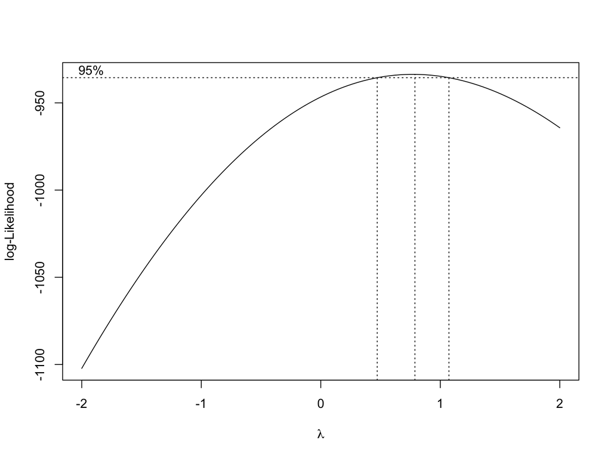

```r
dat <-
  df.lme |>
  as_tibble() |>
  rename(Gesture=head.sample, Dyad=dyad.sample, Answer=answer.t, gdur=g.dur, SubjA=id.a, SubjQ=id.q ) |>
  mutate(SubjA = interaction(SubjA, Dyad, sep=""),
         SubjQ = interaction(SubjQ, Dyad, sep=""),
         Dyad = factor(paste0("D", str_pad(Dyad, width = 1, side = "left", pad = "0")))) |>
  select(Dyad, SubjQ, SubjA, Answer, Gesture, gdur)

MASS::boxcox(gdur ~ 1 + Dyad + SubjA + Answer, data=dat) # looks good.
```

```r
write_feather(dat,  "./data/Raveling_ConversationGap.arrow")
saveRDS(dat, file = "./data/Raveling_ConversationGap.rds")
```

## 6.3 Hyptheses contrasts for `Gesture`

The following is actually an orthogonal set of contrasts. More on this at the SMLP2022.

```r
#dat$Gesture <- factor(dat$Gesture, levels=c("fne", "bne",
#                                            "lti", "rti", "dti", "udti", "duti",
#                                            "lrs", "rls", "uds", "dus" ))

library(hypr)
gstrContr <-
  contr.hypothesis((fne+bne)/2 ~ (lrs+rls+uds+dus)/4,
                   (lti+rti+dti+udti+duti)/5 ~ (lrs+rls+uds+dus)/4,
                   (uds+dus)/2 ~ (lrs+rls)/2,
                   (lti+rti)/2 ~ (udti+duti)/2,
                    dti ~ (lti+rti+udti+duti)/4,
                    lrs ~ rls,
                    uds ~ dus,
                    fne ~ bne,
                    lti ~ rti,
                    udti ~ duti)

contrasts(dat$Gesture) <- gstrContr
contrasts(dat$Answer) <- contr.sum(2)

mm <- model.matrix(~  1 + Gesture*Answer, data=dat)
s_n     <- mm[,2]   # shake - nod
s_t     <- mm[,3]   # shake - tilt
lrs_uds <- mm[,4]   # left-right vs. up-down shake
udt_lrt <- mm[,5]   # up-down vs. left-rght tilt
t_dt    <- mm[,6]   # tilt vs. downward tilt
```

## 6.4 LM check of contrast specification

```r
summary(lm1 <- lm(gdur ~ 1 +  s_n + s_t + lrs_uds + udt_lrt + t_dt, data=dat))
```

```
Call:
lm(formula = gdur ~ 1 + s_n + s_t + lrs_uds + udt_lrt + t_dt,
    data = dat)

Residuals:
     Min       1Q   Median       3Q      Max
-178.837  -87.785    0.584   88.695  188.918

Coefficients:
            Estimate Std. Error t value Pr(>|t|)
(Intercept)  320.725      4.774  67.175   <2e-16 ***
s_n           11.183     13.657   0.819    0.413
s_t            4.310     10.523   0.410    0.682
lrs_uds       36.209     15.251   2.374    0.018 *
udt_lrt       24.955     16.078   1.552    0.121
t_dt          17.414     18.574   0.938    0.349
---
Signif. codes:  0 '***' 0.001 '**' 0.01 '*' 0.05 '.' 0.1 ' ' 1

Residual standard error: 103.2 on 464 degrees of freedom
Multiple R-squared:  0.02007,   Adjusted R-squared:  0.009511
F-statistic: 1.901 on 5 and 464 DF,  p-value: 0.09283
```

```r
summary(lm2 <- lm(gdur ~ 1 + (s_n + s_t + lrs_uds + udt_lrt + t_dt)*Answer, data=dat))
```

```
Call:
lm(formula = gdur ~ 1 + (s_n + s_t + lrs_uds + udt_lrt + t_dt) *
    Answer, data = dat)

Residuals:
     Min       1Q   Median       3Q      Max
-186.051  -89.638    0.569   90.112  199.429

Coefficients:
                Estimate Std. Error t value Pr(>|t|)
(Intercept)      320.320      4.810  66.597   <2e-16 ***
s_n               12.054     13.734   0.878   0.3806
s_t                5.230     10.621   0.492   0.6226
lrs_uds           34.472     15.444   2.232   0.0261 *
udt_lrt           24.720     16.159   1.530   0.1267
t_dt              18.594     18.712   0.994   0.3209
Answer1           -5.233      4.810  -1.088   0.2772
s_n:Answer1       -7.123     13.734  -0.519   0.6042
s_t:Answer1       -4.052     10.621  -0.382   0.7030
lrs_uds:Answer1  -13.936     15.444  -0.902   0.3674
udt_lrt:Answer1   19.481     16.159   1.206   0.2286
t_dt:Answer1      -2.789     18.712  -0.149   0.8816
---
Signif. codes:  0 '***' 0.001 '**' 0.01 '*' 0.05 '.' 0.1 ' ' 1

Residual standard error: 103.5 on 458 degrees of freedom
Multiple R-squared:  0.02816,   Adjusted R-squared:  0.004814
F-statistic: 1.206 on 11 and 458 DF,  p-value: 0.2799
```

```r
anova(lm1, lm2)
```

```
Analysis of Variance Table

Model 1: gdur ~ 1 + s_n + s_t + lrs_uds + udt_lrt + t_dt
Model 2: gdur ~ 1 + (s_n + s_t + lrs_uds + udt_lrt + t_dt) * Answer
  Res.Df     RSS Df Sum of Sq     F Pr(>F)
1    464 4943418
2    458 4902632  6     40787 0.635 0.7022
```

## 6.5 GM-only LMM

**Dyad perspective**

```r
d_voi <- lmer(gdur ~ 1 + s_n + s_t + lrs_uds + udt_lrt + t_dt + (1 | Dyad), data=dat,
              REML=FALSE, control=lmerControl(calc.derivs=FALSE))
```

```
boundary (singular) fit: see help('isSingular')
```

```r
print(summary(d_voi), cor=FALSE)
```

```
Linear mixed model fit by maximum likelihood  ['lmerMod']
Formula: gdur ~ 1 + s_n + s_t + lrs_uds + udt_lrt + t_dt + (1 | Dyad)
   Data: dat
Control: lmerControl(calc.derivs = FALSE)

     AIC      BIC   logLik deviance df.resid
  5702.4   5735.6  -2843.2   5686.4      462

Scaled residuals:
    Min      1Q  Median      3Q     Max
-1.7438 -0.8560  0.0057  0.8648  1.8421

Random effects:
 Groups   Name        Variance Std.Dev.
 Dyad     (Intercept)     0      0.0
 Residual             10518    102.6
Number of obs: 470, groups:  Dyad, 7

Fixed effects:
            Estimate Std. Error t value
(Intercept)  320.725      4.744  67.608
s_n           11.183     13.569   0.824
s_t            4.310     10.455   0.412
lrs_uds       36.209     15.153   2.389
udt_lrt       24.955     15.975   1.562
t_dt          17.414     18.455   0.944
optimizer (nloptwrap) convergence code: 0 (OK)
boundary (singular) fit: see help('isSingular')
```

No reliable variance associated with `Dyad`. Looks like these are random numbers.

**Question perspective**

```r
q_voi <- lmer(gdur ~ 1 + s_n + s_t + lrs_uds + udt_lrt + t_dt + (1 | SubjQ), data=dat,
              REML=FALSE, control=lmerControl(calc.derivs=FALSE))
```

```
boundary (singular) fit: see help('isSingular')
```

```r
print(summary(q_voi), cor=FALSE)
```

```
Linear mixed model fit by maximum likelihood  ['lmerMod']
Formula: gdur ~ 1 + s_n + s_t + lrs_uds + udt_lrt + t_dt + (1 | SubjQ)
   Data: dat
Control: lmerControl(calc.derivs = FALSE)

     AIC      BIC   logLik deviance df.resid
  5702.4   5735.6  -2843.2   5686.4      462

Scaled residuals:
    Min      1Q  Median      3Q     Max
-1.7438 -0.8560  0.0057  0.8648  1.8421

Random effects:
 Groups   Name        Variance Std.Dev.
 SubjQ    (Intercept)     0      0.0
 Residual             10518    102.6
Number of obs: 470, groups:  SubjQ, 14

Fixed effects:
            Estimate Std. Error t value
(Intercept)  320.725      4.744  67.608
s_n           11.183     13.569   0.824
s_t            4.310     10.455   0.412
lrs_uds       36.209     15.153   2.389
udt_lrt       24.955     15.975   1.562
t_dt          17.414     18.455   0.944
optimizer (nloptwrap) convergence code: 0 (OK)
boundary (singular) fit: see help('isSingular')
```

No reliable variance associated with `SubjQ`. Looks like these are random numbers.

**Answer perspective**

```r
a_voi <- lmer(gdur ~ 1 + s_n + s_t + lrs_uds + udt_lrt + t_dt + (1 | SubjA), data=dat,
              REML=FALSE, control=lmerControl(calc.derivs=FALSE))
```

```
boundary (singular) fit: see help('isSingular')
```

```r
print(summary(a_voi), cor=FALSE)
```

```
Linear mixed model fit by maximum likelihood  ['lmerMod']
Formula: gdur ~ 1 + s_n + s_t + lrs_uds + udt_lrt + t_dt + (1 | SubjA)
   Data: dat
Control: lmerControl(calc.derivs = FALSE)

     AIC      BIC   logLik deviance df.resid
  5702.4   5735.6  -2843.2   5686.4      462

Scaled residuals:
    Min      1Q  Median      3Q     Max
-1.7438 -0.8560  0.0057  0.8648  1.8421

Random effects:
 Groups   Name        Variance Std.Dev.
 SubjA    (Intercept)     0      0.0
 Residual             10518    102.6
Number of obs: 470, groups:  SubjA, 14

Fixed effects:
            Estimate Std. Error t value
(Intercept)  320.725      4.744  67.608
s_n           11.183     13.569   0.824
s_t            4.310     10.455   0.412
lrs_uds       36.209     15.153   2.389
udt_lrt       24.955     15.975   1.562
t_dt          17.414     18.455   0.944
optimizer (nloptwrap) convergence code: 0 (OK)
boundary (singular) fit: see help('isSingular')
```

No reliable variance associated with `SubjA`. Looks like these are random numbers.

I assume that Dyad and Subject ids are actually random. However, in principle, it could also be that we don’t have enough observations in the cells of the experimental design.

```r
ctable(dat$Dyad, dat$Gesture, prop="n")
```

```
Cross-Tabulation
Dyad * Gesture
Data Frame: dat

------- --------- ----- ----- ----- ------ ----- ----- ----- ----- ----- ----- ------ -------
          Gesture   bne   dti   dus   duti   fne   lrs   lti   rls   rti   uds   udti   Total
   Dyad
     D1               6     5     5      8    11     8     1     5     8     9      3      69
     D2               3     3    10      9     8     8     7     4     2     6      6      66
     D3               6     9     6     11     4     8     9     7    12     7      2      81
     D4               6     4     6      1     6     7     4     7     5     8      6      60
     D5               4     2     7      7     5     6     5     5     5     9      8      63
     D6               5     8     4      6     6     4     5     7     7     9      4      65
     D7               7     7     6      5     6     7     5     3     5     6      9      66
  Total              37    38    44     47    46    48    36    38    44    54     38     470
------- --------- ----- ----- ----- ------ ----- ----- ----- ----- ----- ----- ------ -------
```

```r
ctable(dat$SubjQ, dat$Gesture, prop="n")
```

```
Cross-Tabulation
SubjQ * Gesture
Data Frame: dat

------- --------- ----- ----- ----- ------ ----- ----- ----- ----- ----- ----- ------ -------
          Gesture   bne   dti   dus   duti   fne   lrs   lti   rls   rti   uds   udti   Total
  SubjQ
     A1               2     2     3      1     7     2     1     4     5     4      2      33
     B1               4     3     2      7     4     6     0     1     3     5      1      36
     A2               2     2     6      5     5     4     2     3     1     4      4      38
     B2               1     1     4      4     3     4     5     1     1     2      2      28
     A3               3     4     1      5     2     7     6     4     7     2      1      42
     B3               3     5     5      6     2     1     3     3     5     5      1      39
     A4               3     1     5      0     1     5     2     3     2     2      3      27
     B4               3     3     1      1     5     2     2     4     3     6      3      33
     A5               3     1     4      2     2     3     4     2     3     4      4      32
     B5               1     1     3      5     3     3     1     3     2     5      4      31
     A6               3     4     0      3     2     4     3     2     1     7      1      30
     B6               2     4     4      3     4     0     2     5     6     2      3      35
     A7               4     5     4      2     2     3     3     2     1     5      2      33
     B7               3     2     2      3     4     4     2     1     4     1      7      33
  Total              37    38    44     47    46    48    36    38    44    54     38     470
------- --------- ----- ----- ----- ------ ----- ----- ----- ----- ----- ----- ------ -------
```

These numbers are small, but in principle we should get somewhere. However, this is also a nice example, to demonstrate how we can simplify the design. So let’s carry on.

# 7 Second Attempt

## 7.1 Collapse factor levels

Let’s collapse Gesture cells according to the top-contrast categories.

```r
dat$Gest2 <-
  fct_collapse(dat$Gesture, lrs = c("lrs", "rls"),
                            uds = c("uds", "dus"),
                            lrt = c("lti", "rti"),
                            udt = c("udti", "duti", "dti"),
                            nod = c("bne", "fne"))

dat$Gest2 <- factor(dat$Gest2,
                       levels=c("lrs", "lrt", "nod", "uds", "udt"))

ctable(dat$Dyad,dat$Gest2, prop="n")
```

```
Cross-Tabulation
Dyad * Gest2
Data Frame: dat

------- ------- ----- ----- ----- ----- ----- -------
          Gest2   lrs   lrt   nod   uds   udt   Total
   Dyad
     D1            13     9    17    14    16      69
     D2            12     9    11    16    18      66
     D3            15    21    10    13    22      81
     D4            14     9    12    14    11      60
     D5            11    10     9    16    17      63
     D6            11    12    11    13    18      65
     D7            10    10    13    12    21      66
  Total            86    80    83    98   123     470
------- ------- ----- ----- ----- ----- ----- -------
```

```r
ctable(dat$SubjQ, dat$Gest2, prop="n")
```

```
Cross-Tabulation
SubjQ * Gest2
Data Frame: dat

------- ------- ----- ----- ----- ----- ----- -------
          Gest2   lrs   lrt   nod   uds   udt   Total
  SubjQ
     A1             6     6     9     7     5      33
     B1             7     3     8     7    11      36
     A2             7     3     7    10    11      38
     B2             5     6     4     6     7      28
     A3            11    13     5     3    10      42
     B3             4     8     5    10    12      39
     A4             8     4     4     7     4      27
     B4             6     5     8     7     7      33
     A5             5     7     5     8     7      32
     B5             6     3     4     8    10      31
     A6             6     4     5     7     8      30
     B6             5     8     6     6    10      35
     A7             5     4     6     9     9      33
     B7             5     6     7     3    12      33
  Total            86    80    83    98   123     470
------- ------- ----- ----- ----- ----- ----- -------
```

## 7.2 Contrasts

```r
gstrContr2 <-
  contr.hypothesis( nod        ~ (uds+lrs)/2,
                   (udt+lrt)/2 ~ (uds+lrs)/2,
                    uds ~ lrs,
                    lrt ~ udt)

contrasts(dat$Gest2) <- gstrContr2
contrasts(dat$Answer) <- contr.sum(2)

mm <- model.matrix(~  1 + Gest2, data=dat)
dat$c1 <- mm[,2]   # shake - nod
dat$c2 <- mm[,3]   # shake - tilt
dat$c3 <- mm[,4]   # left-right vs. up-down shake
dat$c4 <- mm[,5]   # up-down vs. left-rght tilt
```

## 7.3 LM check of contrast specification

We can also use the factor itself. Compare!

```r
summary(lm3 <- lm(gdur ~ 1 +  c1 + c2 + c3 + c4, data=dat))
```

```
Call:
lm(formula = gdur ~ 1 + c1 + c2 + c3 + c4, data = dat)

Residuals:
     Min       1Q   Median       3Q      Max
-178.837  -87.916    2.023   89.320  182.372

Coefficients:
            Estimate Std. Error t value Pr(>|t|)
(Intercept)  321.147      4.826  66.546   <2e-16 ***
c1            11.183     13.674   0.818   0.4139
c2             5.445     10.648   0.511   0.6094
c3            36.209     15.271   2.371   0.0181 *
c4            15.720     14.845   1.059   0.2901
---
Signif. codes:  0 '***' 0.001 '**' 0.01 '*' 0.05 '.' 0.1 ' ' 1

Residual standard error: 103.4 on 465 degrees of freedom
Multiple R-squared:  0.01542,   Adjusted R-squared:  0.00695
F-statistic: 1.821 on 4 and 465 DF,  p-value: 0.1237
```

```r
summary(lm3a <- lm(gdur ~ 1 + Gest2, data=dat))
```

```
Call:
lm(formula = gdur ~ 1 + Gest2, data = dat)

Residuals:
     Min       1Q   Median       3Q      Max
-178.837  -87.916    2.023   89.320  182.372

Coefficients:
            Estimate Std. Error t value Pr(>|t|)
(Intercept)  321.147      4.826  66.546   <2e-16 ***
Gest21        11.183     13.674   0.818   0.4139
Gest22         5.445     10.648   0.511   0.6094
Gest23        36.209     15.271   2.371   0.0181 *
Gest24        15.720     14.845   1.059   0.2901
---
Signif. codes:  0 '***' 0.001 '**' 0.01 '*' 0.05 '.' 0.1 ' ' 1

Residual standard error: 103.4 on 465 degrees of freedom
Multiple R-squared:  0.01542,   Adjusted R-squared:  0.00695
F-statistic: 1.821 on 4 and 465 DF,  p-value: 0.1237
```

```r
anova(lm3, lm3a)
```

```
Analysis of Variance Table

Model 1: gdur ~ 1 + c1 + c2 + c3 + c4
Model 2: gdur ~ 1 + Gest2
  Res.Df     RSS Df Sum of Sq F Pr(>F)
1    465 4966881
2    465 4966881  0         0
```

**Dyad perspective**

```r
d_voi <- lmer(gdur ~ 1 + Gest2 + (1 | Dyad), data=dat,
              REML=FALSE, control=lmerControl(calc.derivs=FALSE))
```

```
boundary (singular) fit: see help('isSingular')
```

```r
print(summary(d_voi), cor=FALSE)
```

```
Linear mixed model fit by maximum likelihood  ['lmerMod']
Formula: gdur ~ 1 + Gest2 + (1 | Dyad)
   Data: dat
Control: lmerControl(calc.derivs = FALSE)

     AIC      BIC   logLik deviance df.resid
  5702.6   5731.7  -2844.3   5688.6      463

Scaled residuals:
     Min       1Q   Median       3Q      Max
-1.73966 -0.85521  0.01968  0.86887  1.77405

Random effects:
 Groups   Name        Variance Std.Dev.
 Dyad     (Intercept)     0      0.0
 Residual             10568    102.8
Number of obs: 470, groups:  Dyad, 7

Fixed effects:
            Estimate Std. Error t value
(Intercept)  321.147      4.800  66.902
Gest21        11.183     13.602   0.822
Gest22         5.445     10.592   0.514
Gest23        36.209     15.189   2.384
Gest24        15.720     14.765   1.065
optimizer (nloptwrap) convergence code: 0 (OK)
boundary (singular) fit: see help('isSingular')
```

**Question perspective**

```r
q_voi <- lmer(gdur ~ 1 + Gest2 +  (1 | SubjQ), data=dat,
              REML=FALSE, control=lmerControl(calc.derivs=FALSE))
```

```
boundary (singular) fit: see help('isSingular')
```

```r
print(summary(q_voi), cor=FALSE)
```

```
Linear mixed model fit by maximum likelihood  ['lmerMod']
Formula: gdur ~ 1 + Gest2 + (1 | SubjQ)
   Data: dat
Control: lmerControl(calc.derivs = FALSE)

     AIC      BIC   logLik deviance df.resid
  5702.6   5731.7  -2844.3   5688.6      463

Scaled residuals:
     Min       1Q   Median       3Q      Max
-1.73966 -0.85521  0.01968  0.86887  1.77405

Random effects:
 Groups   Name        Variance Std.Dev.
 SubjQ    (Intercept)     0      0.0
 Residual             10568    102.8
Number of obs: 470, groups:  SubjQ, 14

Fixed effects:
            Estimate Std. Error t value
(Intercept)  321.147      4.800  66.902
Gest21        11.183     13.602   0.822
Gest22         5.445     10.592   0.514
Gest23        36.209     15.189   2.384
Gest24        15.720     14.765   1.065
optimizer (nloptwrap) convergence code: 0 (OK)
boundary (singular) fit: see help('isSingular')
```

**Answer perspective**

```r
a_voi <- lmer(gdur ~ 1 + Gest2 + (1 | SubjA), data=dat,
              REML=FALSE, control=lmerControl(calc.derivs=FALSE))
```

```
boundary (singular) fit: see help('isSingular')
```

```r
print(summary(a_voi), corr=FALSE)
```

```
Linear mixed model fit by maximum likelihood  ['lmerMod']
Formula: gdur ~ 1 + Gest2 + (1 | SubjA)
   Data: dat
Control: lmerControl(calc.derivs = FALSE)

     AIC      BIC   logLik deviance df.resid
  5702.6   5731.7  -2844.3   5688.6      463

Scaled residuals:
     Min       1Q   Median       3Q      Max
-1.73966 -0.85521  0.01968  0.86887  1.77405

Random effects:
 Groups   Name        Variance Std.Dev.
 SubjA    (Intercept)     0      0.0
 Residual             10568    102.8
Number of obs: 470, groups:  SubjA, 14

Fixed effects:
            Estimate Std. Error t value
(Intercept)  321.147      4.800  66.902
Gest21        11.183     13.602   0.822
Gest22         5.445     10.592   0.514
Gest23        36.209     15.189   2.384
Gest24        15.720     14.765   1.065
optimizer (nloptwrap) convergence code: 0 (OK)
boundary (singular) fit: see help('isSingular')
```

No reliable variance associated with `Dyad`, `SubjQ`, and `SubA`. It still looks like these are random numbers. Julia MixedModels cannot help here either.

# 8 Appendix